# RCBD vs. Alpha Lattice for a 7 × 7 North Carolina II Trial

- Show All Code
- Hide All Code
- View Source

Two independent design axes — the line × tester *mating* design and the *field layout* — illustrated with FielDHub and Stelio’s `data/multilocation.csv`

Author

Fausto Rodriguez Zapata

Published

June 15, 2026

**Source code & data:** https://github.com/faustovrz/gcamoz

**Note**

This is a **companion / didactic** notebook to `multilocation_alpha_lattice.qmd`. Its only job is to answer one question cleanly: **how does a “RCBD with a 7 × 7 NC II design” differ from an “alpha lattice design”?** — and **is an alpha-lattice field distribution compatible with `data/multilocation.csv`?**

It does **not** redo the GCA/SCA analysis (that lives in `multilocation_alpha_lattice.qmd`). It fits a plain RCBD on the real yields to anchor the discussion, generates an alpha lattice with **FielDHub** to make the alternative concrete, and lays the two side by side.

# 1 The Single Most Important Idea

The phrase *“RCBD with a 7 × 7 NC II design”* and the phrase *“alpha lattice design”* are **not two options on the same menu.** They live on two **independent axes**, and you choose one value on *each* axis:

| Axis | What it decides | Your trial | Alternatives |
| --- | --- | --- | --- |
| **1. Mating design** | *How the genotypes were created* — which parents were crossed. Drives the **genetic analysis** (GCA / SCA). | **7 × 7 line × tester = North Carolina Design II**: 7 CIMMYT females × 7 IIAM (EN) males → 49 F1 hybrids. | Diallel, NC I, NC III, topcross, single-cross panel … |
| **2. Field layout (blocking)** | *How the plots are arranged in the soil* to soak up field heterogeneity. Drives the **error-control / blocking term** in the model. | **?** — this is exactly what is unresolved: **RCBD** or **alpha lattice**. | RCBD, alpha lattice, square/rectangular lattice, augmented, row–column, p-rep … |

**Important**

**The mating design and the field layout are orthogonal.** The 7 × 7 NC II does **not** commit you to any particular field layout. The *same* 49 hybrids (+ check) can be fielded as an **RCBD** *or* as an **alpha lattice** — only the **blocking term** in the model changes. So the real comparison in this notebook is:

> **RCBD vs. alpha lattice — two ways to lay the *same* NC II material in the field.**

“7 × 7 NC II” is a constant on both sides of that comparison; it is *not* the thing being compared.

This is why the question “is it RCBD or alpha?” is a **field-layout** question, answered by the *plot arrangement* (is each rep one complete block, or split into incomplete sub-blocks?), and is completely separate from the line × tester genetics.

# 2 R Setup

```r
library(tidyverse)
library(FielDHub)   # alpha-lattice generation; install.packages("FielDHub") if missing
library(lme4)       # lightweight mixed model to anchor the RCBD fit
library(knitr)
library(kableExtra)

raw_data <- read_csv("data/multilocation.csv", show_col_types = FALSE) %>%
  mutate(
    file_order = row_number(),                    # as-entered plot order (entry is damaged)
    ENV    = factor(env),
    REP    = factor(rep, levels = c("I", "II", "III")),
    GEN    = factor(gen, levels = as.character(0:49)),
    Female = factor(female),
    Male   = factor(male),
    cross  = factor(hybrid),
    yield  = GY
  )

# Hybrids-only frame (check held out), mirroring the companion notebook.
hybrids <- raw_data %>%
  filter(GEN != "0") %>%
  transmute(env = droplevels(ENV), rep = REP,
            female = droplevels(Female), male = droplevels(Male),
            cross = droplevels(cross), yield = yield)
```

# 3 The Mating Design: 7 × 7 North Carolina II (held constant)

The genetic material is a **factorial / line × tester** cross — Comstock & Robinson’s **North Carolina Design II** (Comstock & Robinson, 1948; Isik et al., 2017). Two disjoint parent sets are crossed in every combination:

- **Females / lines:** 7 CIMMYT CML donors.
- **Males / testers:** 7 IIAM testers (`EN17`, `EN20`, `EN21`, `EN25`, `EN31`, `EN32`, `EN64`).
- **Hybrids:** all 7 × 7 = **49 F1 combinations**, plus a repeated `NAMULONGUE` **check** → **50 entries** evaluated per replication.

```r
mating_grid <- raw_data %>%
  filter(GEN != "0") %>%
  distinct(Female, Male, GEN) %>%
  droplevels() %>%
  arrange(Female, Male) %>%
  pivot_wider(names_from = Male, values_from = GEN)

kable(mating_grid,
      caption = "The 7 × 7 NC II mating grid (cell = GEN code). This is FIXED — it is the same whether the field is RCBD or alpha lattice.") %>%
  kable_styling(bootstrap_options = c("striped", "hover", "condensed"))
```

The 7 × 7 NC II mating grid (cell = GEN code). This is FIXED — it is the same whether the field is RCBD or alpha lattice.

| Female | EN17 | EN20 | EN21 | EN25 | EN31 | EN32 | EN64 |
| --- | --- | --- | --- | --- | --- | --- | --- |
| CML364 | 1 | 8 | 15 | 22 | 29 | 36 | 43 |
| CML366 | 2 | 9 | 16 | 23 | 30 | 37 | 44 |
| CML434 | 3 | 10 | 17 | 24 | 31 | 38 | 45 |
| CML435 | 4 | 11 | 18 | 25 | 32 | 39 | 46 |
| CML439 | 5 | 12 | 19 | 26 | 33 | 40 | 47 |
| CML530 | 6 | 13 | 20 | 27 | 34 | 41 | 48 |
| CML532 | 7 | 14 | 21 | 28 | 35 | 42 | 49 |

**Note**

Everything below changes the **field layout** around these 50 entries. The grid above never changes. Keep this picture in mind: the NC II decides *what is in the plots*; RCBD vs. alpha decides *which plots sit next to which, inside which block*.

# 4 Field Layout Option A — RCBD (Complete Blocks)

In a **Randomized Complete Block Design**, each replication is **one complete block** containing **all 50 entries exactly once**, arranged in random order within the block.

- **Block = replication.** Here that is the 5 × 10 = 50-plot grid per rep.
- **Assumption:** the soil is reasonably **uniform *within* a whole replication**, so a single block-mean adjustment per rep removes the between-rep field effect.
- **Blocking term:** one factor — `rep` (nested in `env` for the multilocation trial: `env:rep`).

```r
rcbd_schematic <- tibble(
  Property               = c("Block unit", "Plots per block", "Entries per block",
                             "Blocks per rep", "Incomplete sub-blocks?", "Blocking term(s)"),
  RCBD                   = c("Replication (whole rep)", "50", "All 50 (complete)",
                             "1", "No", "rep  (→ env:rep)")
)
kable(rcbd_schematic, caption = "RCBD blocking structure for the 50 entries") %>%
  kable_styling(bootstrap_options = c("striped", "hover", "condensed"))
```

RCBD blocking structure for the 50 entries

| Property | RCBD |
| --- | --- |
| Block unit | Replication (whole rep) |
| Plots per block | 50 |
| Entries per block | All 50 (complete) |
| Blocks per rep | 1 |
| Incomplete sub-blocks? | No |
| Blocking term(s) | rep (→ env:rep) |

**RCBD model for grain yield** (NC II genetics layered on the RCBD blocking):

$$y_{hi(pq)} = \mu + E_h + R_{i(h)} + g_{F_p} + g_{M_q} + s_{pq} + (\text{G}\times\text{E})_{h(pq)} + \epsilon_{hi(pq)}$$

where $R_{i(h)}$ — replication-within-environment — is the **only** field-control term: one adjustment for the *entire* rep.

```r
# Anchor RCBD fit on the REAL yields (check excluded). env fixed; rep the
# complete-block term; female/male/cross the NC II genetics — all random.
rcbd_fit <- lmer(
  yield ~ env + (1 | env:rep) +
    (1 | female) + (1 | male) + (1 | cross),
  data = hybrids
)

rcbd_vc <- as.data.frame(VarCorr(rcbd_fit)) %>%
  transmute(Term = grp, Variance = round(vcov, 4))

kable(rcbd_vc,
      caption = "RCBD variance components on the real grain yield (GY, t/ha; env:rep = the single complete-block term).") %>%
  kable_styling(bootstrap_options = c("striped", "hover", "condensed"))
```

RCBD variance components on the real grain yield (GY, t/ha; env:rep = the single complete-block term).

| Term | Variance |
| --- | --- |
| cross | 0.0479 |
| env:rep | 0.3665 |
| male | 0.0000 |
| female | 0.0656 |
| Residual | 2.9580 |

**Note**

The companion notebook refines this RCBD with row/column spatial terms recovered from the planting order. That row/column trick is a *spatial* correction **on top of** the RCBD — it is **not** an alpha lattice. An alpha lattice instead controls field trend through **explicitly randomized incomplete blocks**, which is the next section.

# 5 Field Layout Option B — Alpha Lattice (Incomplete Blocks)

A complete block of 50 plots can be large enough that the soil is **not** uniform across it — there is gradient *within* the rep that one rep-mean cannot remove. The **alpha lattice** (an α-design, Patterson & Williams (1976)) fixes this by **subdividing each replication into smaller incomplete blocks** and randomizing entries into them.

Key vocabulary, for $t$ treatments:

- **$k$ — block size:** plots per incomplete block (here we choose **$k = 5$**).
- **$s = t/k$ — blocks per replication:** here $50/5 =$ **10 incomplete blocks per rep**.
- **$r$ — replications:** here **3**.
- **Resolvable:** every replication still contains a *complete* set of all $t$ entries — the incomplete blocks **partition** each rep. This is why an alpha lattice can always *fall back* to being analyzed as an RCBD.

```r
alpha_schematic <- tibble(
  Property               = c("Block unit", "Plots per block", "Entries per block",
                             "Blocks per rep", "Incomplete sub-blocks?", "Blocking term(s)"),
  `Alpha lattice (k = 5)` = c("Incomplete block (within rep)", "5", "5 of 50 (incomplete)",
                              "10", "Yes — 10 per rep", "rep + rep:block")
)
kable(alpha_schematic, caption = "Alpha-lattice blocking structure for the 50 entries (k = 5)") %>%
  kable_styling(bootstrap_options = c("striped", "hover", "condensed"))
```

Alpha-lattice blocking structure for the 50 entries (k = 5)

| Property | Alpha lattice (k = 5) |
| --- | --- |
| Block unit | Incomplete block (within rep) |
| Plots per block | 5 |
| Entries per block | 5 of 50 (incomplete) |
| Blocks per rep | 10 |
| Incomplete sub-blocks? | Yes — 10 per rep |
| Blocking term(s) | rep + rep:block |

**Alpha-lattice model for grain yield** — identical NC II genetics, but the blocking gains a nested **incomplete-block** term:

$$y_{hib(pq)} = \mu + E_h + R_{i(h)} + \underbrace{B_{b(hi)}}_{\textbf{new}} + g_{F_p} + g_{M_q} + s_{pq} + (\text{G}\times\text{E})_{h(pq)} + \epsilon_{hib(pq)}$$

The **only** structural difference from the RCBD model is the added term $B_{b(hi)}$ — the **incomplete block nested within replication** (`env:rep:block`). That single term is what makes it an alpha lattice rather than an RCBD.

|  | RCBD | Alpha lattice |
| --- | --- | --- |
| Field-control terms | `env:rep` | `env:rep` **+ `env:rep:block`** |
| Uniformity assumed over | the whole rep (50 plots) | only a 5-plot block |
| Recovers within-rep gradient? | No | **Yes** |
| Needs sub-block label per plot? | No | **Yes** |
| Can be analyzed as RCBD? | — | Yes (drop the block term) |

# 6 Generating an Alpha Lattice with FielDHub

Now we make Option B concrete. **FielDHub** (Aparicio et al., 2023) generates a *resolvable* alpha lattice and gives every plot an explicit **incomplete-block label** — the column that the CSV currently lacks.

We request **$t = 50$** entries, block size **$k = 5$** (→ $s = 10$ blocks/rep), **$r = 3$** replications, one location.

```r
alpha_design <- alpha_lattice(
  t            = 50,     # entries: 49 hybrids + 1 check
  k            = 5,      # incomplete-block size
  r            = 3,      # replications
  l            = 1,      # one location (repeat per environment in the real trial)
  plotNumber   = 101,
  locationNames = "ALPHA-DEMO",
  seed         = 1234
)

field_book <- alpha_design$fieldBook %>% as_tibble()

# Show the structure FielDHub produces — the key column is the incomplete block.
kable(head(field_book, 12),
      caption = "First 12 plots of the FielDHub alpha lattice. Each plot carries a REP and an incomplete-block (IBLOCK) label — the block label is what an alpha analysis needs.") %>%
  kable_styling(bootstrap_options = c("striped", "hover", "condensed")) %>%
  scroll_box(height = "360px")
```

First 12 plots of the FielDHub alpha lattice. Each plot carries a REP and an incomplete-block (IBLOCK) label — the block label is what an alpha analysis needs.

| ID | LOCATION | PLOT | REP | IBLOCK | UNIT | ENTRY | TREATMENT |
| --- | --- | --- | --- | --- | --- | --- | --- |
| 1 | ALPHA-DEMO | 101 | 1 | 1 | 1 | 11 | G-11 |
| 2 | ALPHA-DEMO | 102 | 1 | 1 | 2 | 31 | G-31 |
| 3 | ALPHA-DEMO | 103 | 1 | 1 | 3 | 37 | G-37 |
| 4 | ALPHA-DEMO | 104 | 1 | 1 | 4 | 23 | G-23 |
| 5 | ALPHA-DEMO | 105 | 1 | 1 | 5 | 48 | G-48 |
| 6 | ALPHA-DEMO | 106 | 1 | 2 | 1 | 24 | G-24 |
| 7 | ALPHA-DEMO | 107 | 1 | 2 | 2 | 17 | G-17 |
| 8 | ALPHA-DEMO | 108 | 1 | 2 | 3 | 1 | G-1 |
| 9 | ALPHA-DEMO | 109 | 1 | 2 | 4 | 18 | G-18 |
| 10 | ALPHA-DEMO | 110 | 1 | 2 | 5 | 13 | G-13 |
| 11 | ALPHA-DEMO | 111 | 1 | 3 | 1 | 41 | G-41 |
| 12 | ALPHA-DEMO | 112 | 1 | 3 | 2 | 19 | G-19 |

```r
structure_summary <- field_book %>%
  summarize(
    total_plots        = n(),
    replications       = n_distinct(REP),
    entries            = n_distinct(ENTRY),
    iblocks_per_rep    = n_distinct(IBLOCK),
    plots_per_iblock   = n() / (n_distinct(REP) * n_distinct(IBLOCK))
  )

kable(structure_summary,
      caption = "The generated design: 3 reps × 10 incomplete blocks × 5 plots = 150 plots; 50 entries each appearing once per rep.") %>%
  kable_styling(bootstrap_options = c("striped", "hover", "condensed"))
```

The generated design: 3 reps × 10 incomplete blocks × 5 plots = 150 plots; 50 entries each appearing once per rep.

| total_plots | replications | entries | iblocks_per_rep | plots_per_iblock |
| --- | --- | --- | --- | --- |
| 150 | 3 | 50 | 10 | 5 |

## 6.1 Field Map on the 5 × 10 Serpentine

To place the generated design on the actual field, we reuse the **5-column × 10-row serpentine** from `multilocation_alpha_lattice.qmd` — but derive the row/column from FielDHub’s **planting order** rather than any built-in coordinate column. We start the serpentine at the **top-right** corner (first plot at row 1, column 5) and snake down.

Because consecutive plots in a resolvable alpha lattice belong to the same incomplete block, and here **block size k = 5 equals the field width (5 columns)**, **each incomplete block falls on exactly one serpentine row.** The colour bands (blocks) therefore line up with field rows — the visual signature of an alpha lattice. An RCBD map of the same rep would carry **no internal block boundaries** — just 50 plots in one undifferentiated block.

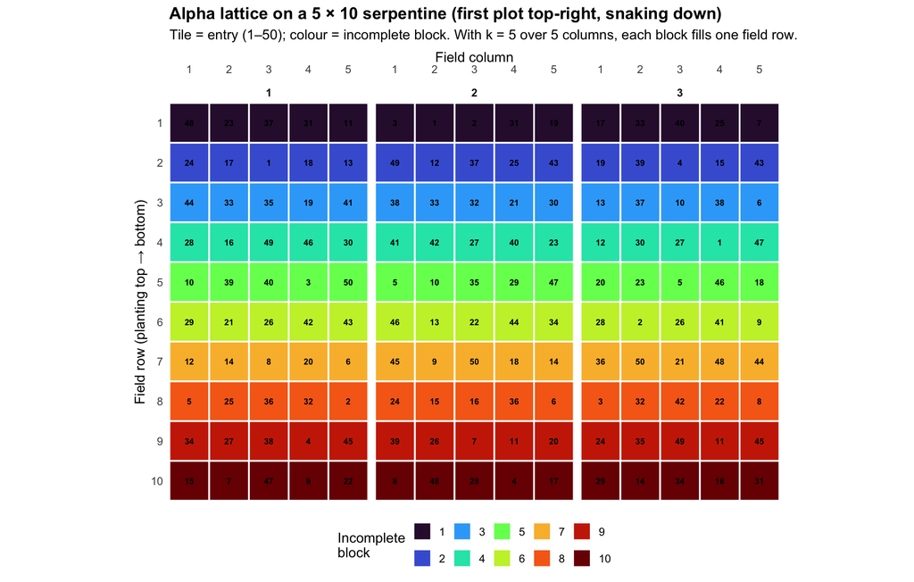

```r
# Same serpentine convention as multilocation_alpha_lattice.qmd: 5 columns × 10
# rows per rep, derived from the planting order (PLOT). First plot top-right,
# odd rows run right→left, even rows left→right, snaking down the block.
alpha_layout <- field_book %>%
  arrange(REP, PLOT) %>%
  group_by(REP) %>%
  mutate(
    plot_order = row_number(),                    # 1 .. 50 within each rep
    field_row  = ceiling(plot_order / 5),         # 1 (top) .. 10 (bottom)
    pos_in_row = ((plot_order - 1) %% 5) + 1,
    field_col  = if_else(field_row %% 2 == 1,     # serpentine from TOP-RIGHT:
                         6L - pos_in_row,          #   odd rows  right → left
                         pos_in_row)               #   even rows left  → right
  ) %>%
  ungroup() %>%
  mutate(IBLOCK = factor(IBLOCK))

ggplot(alpha_layout, aes(x = field_col, y = field_row, fill = IBLOCK)) +
  geom_tile(color = "white", linewidth = 0.7) +
  geom_text(aes(label = ENTRY), size = 2.6, fontface = "bold") +
  facet_wrap(~ REP, nrow = 1) +
  scale_fill_viridis_d(option = "turbo", name = "Incomplete\nblock") +
  scale_x_continuous(breaks = 1:5, position = "top", expand = c(0, 0)) +
  scale_y_reverse(breaks = 1:10, expand = c(0, 0)) +
  coord_equal() +
  labs(
    title    = "Alpha lattice on a 5 × 10 serpentine (first plot top-right, snaking down)",
    subtitle = "Tile = entry (1–50); colour = incomplete block. With k = 5 over 5 columns, each block fills one field row.",
    x = "Field column", y = "Field row (planting top → bottom)"
  ) +
  theme_minimal(base_size = 12) +
  theme(panel.grid      = element_blank(),
        strip.text      = element_text(face = "bold"),
        plot.title      = element_text(face = "bold"),
        legend.position = "bottom")
```

**Warning**

# 7 Compatibility with `data/multilocation.csv`

**Is a North Carolina (NC II) breeding design distributed in the field as an alpha lattice compatible with this data?** Two layers to the answer.

**1. Genetically — yes, trivially.** The NC II / 7 × 7 line × tester analysis is *independent* of the field layout (see Section 1). The same `female` / `male` / `cross` GCA-SCA model runs whether the blocking term is `env:rep` (RCBD) or `env:rep` + `env:rep:block` (alpha). Switching to an alpha lattice changes **nothing** in the genetic decomposition.

**2. As a field layout — dimensionally yes, but not analyzable from the current file.**

```r
compat <- tibble(
  Requirement = c(
    "Entries (t)",
    "Factors cleanly into incomplete blocks?",
    "Replications (r ≥ 2)",
    "Sub-block (IBLOCK) label per plot present in CSV?"
  ),
  `Stelio's data` = c(
    paste0(n_distinct(raw_data$GEN), " (49 hybrids + 1 check)"),
    "Yes — 50 = 10 × 5 (k = 5) or 5 × 10 (k = 10)",
    paste0(n_distinct(raw_data$REP), " (I, II, III)"),
    "NO — the CSV has ENV, REP, GEN, pedigree, traits, but no block column"
  ),
  Verdict = c("✅ fits an alpha lattice", "✅", "✅", "❌ blocks her")
)

kable(compat, caption = "Alpha-lattice compatibility audit of data/multilocation.csv") %>%
  kable_styling(bootstrap_options = c("striped", "hover", "condensed"))
```

Alpha-lattice compatibility audit of data/multilocation.csv

[output not shown]

## 7.1 Empirical test — is there any incomplete-block signal?

Dimensional compatibility is necessary but not sufficient: 50 = 10 × 5 simply means an alpha lattice *would fit*, not that one was *used*. We can test the latter directly, because an α-design is fundamentally **just a restriction on co-occurrence** (Patterson & Williams, 1976): within the replications of one environment, a resolvable **α(0,1)-lattice** lets **every genotype pair share an incomplete block at most once**. So if the field rows (the only contiguous $k = 5$ grouping in a 5 × 10 layout, giving $s = 10$ blocks/rep) were real incomplete blocks, a census of how often each of the $\binom{50}{2} = 1225$ pairs lands in the same row must show **only counts 0 and 1** — never 2.

Two references bracket the result: the **ideal α(0,1) lattice** (deterministic — $r \cdot s \cdot \binom{k}{2} = 3 \cdot 10 \cdot 10 = 300$ pairs concur once, 925 concur zero, nothing at 2+) and a **random RCBD** (50 entries thrown at random into the 10 rows, 1000 sims — what “no block structure” looks like).

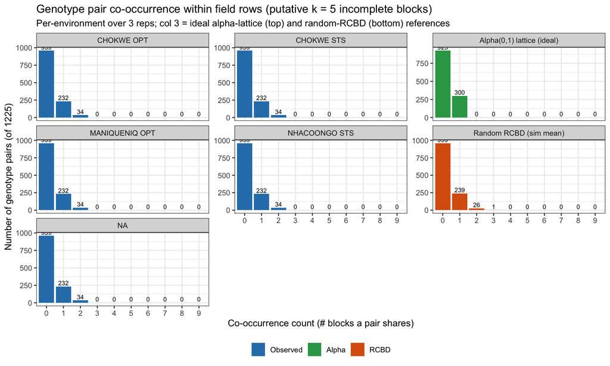

```r
set.seed(20260616)
maxc <- 9   # display range for co-occurrence counts

# Recover the field row (putative k = 5 incomplete block) from the serpentine
# planting order, exactly as multilocation_alpha_lattice.qmd does. (Serpentine
# direction sets the column only; row membership is just groups of 5 along the
# planting sequence — we use file order because the entry column is damaged.)
blk <- raw_data %>%
  group_by(ENV, REP) %>%
  arrange(file_order, .by_group = TRUE) %>%
  mutate(plot_order = row_number(),
         field_row  = ceiling(plot_order / 5)) %>%
  ungroup() %>%
  mutate(gen = as.integer(as.character(GEN)))

gens <- sort(unique(blk$gen))                       # 0..49 -> 50 genotypes
all_keys <- combn(gens, 2, FUN = function(p) paste(p[1], p[2], sep = "_"))

# co-occurrence count for every pair, given the columns that define a block
cooc_counts <- function(data, block_cols) {
  cnt <- data %>%
    group_by(across(all_of(block_cols))) %>%
    summarise(pk = list(combn(sort(gen), 2,
                              FUN = function(p) paste(p[1], p[2], sep = "_"))),
              .groups = "drop") %>%
    tidyr::unnest(pk) %>%
    count(pk, name = "cooc")
  tibble(pk = all_keys) %>%
    left_join(cnt, by = "pk") %>%
    mutate(cooc = tidyr::replace_na(cooc, 0L)) %>%
    pull(cooc)
}

dist_row <- function(counts, panel, type)
  tibble(count = 0:maxc,
         pairs = as.integer(table(factor(counts, levels = 0:maxc))),
         panel = panel, type = type)

envs <- levels(droplevels(raw_data$ENV))

# Observed: per environment, across its 3 reps, block = field row
obs_df <- bind_rows(lapply(envs, function(e)
  dist_row(cooc_counts(filter(blk, ENV == e), c("REP", "field_row")),
           panel = e, type = "Observed")))

# Reference 1 — random-RCBD expectation: permute 50 genotypes into 10 rows, 1000 sims
n_sim <- 1000
sim_block <- expand.grid(REP = 1:3, field_row = 1:10, slot = 1:5)
sim_acc <- numeric(maxc + 1)
for (s in seq_len(n_sim)) {
  d <- sim_block
  d$gen <- unlist(lapply(1:3, function(r) sample(gens, 50)))
  cc <- cooc_counts(d, c("REP", "field_row"))
  sim_acc <- sim_acc + as.integer(table(factor(cc, levels = 0:maxc)))
}
sim_df <- tibble(count = 0:maxc, pairs = sim_acc / n_sim,
                 panel = "Random RCBD (sim mean)", type = "RCBD")

# Reference 2 — ideal alpha(0,1) lattice (deterministic): 300 pairs at 1, 925 at 0
alpha_pairs <- numeric(maxc + 1); alpha_pairs[1] <- 925; alpha_pairs[2] <- 300
alpha_df <- tibble(count = 0:maxc, pairs = alpha_pairs,
                   panel = "Alpha(0,1) lattice (ideal)", type = "Alpha")

# 2 x 3 grid: envs fill cols 1-2; col 3 = ideal alpha (top), random RCBD (bottom)
plot_all <- bind_rows(obs_df, sim_df, alpha_df) %>%
  mutate(
    panel = factor(panel, levels = c(envs[1], envs[2], "Alpha(0,1) lattice (ideal)",
                                     envs[3], envs[4], "Random RCBD (sim mean)")),
    type  = factor(type, levels = c("Observed", "Alpha", "RCBD"))
  )

ggplot(plot_all, aes(factor(count), pairs, fill = type)) +
  geom_col() +
  geom_text(aes(label = round(pairs)), vjust = -0.3, size = 2.6) +
  facet_wrap(~ panel, ncol = 3, scales = "free_y") +
  scale_fill_manual(values = c(Observed = "#2c7fb8", Alpha = "#31a354",
                               RCBD = "#d95f0e")) +
  labs(
    title = "Genotype pair co-occurrence within field rows (putative k = 5 incomplete blocks)",
    subtitle = "Per-environment over 3 reps; col 3 = ideal alpha-lattice (top) and random-RCBD (bottom) references",
    x = "Co-occurrence count (# blocks a pair shares)",
    y = "Number of genotype pairs (of 1225)",
    fill = NULL
  ) +
  theme_bw(base_size = 11) +
  theme(legend.position = "bottom")
```

The same census can be read as a **block-adjacency graph**: a 50 × 50 matrix whose cell $C_{ij}$ counts the blocks genotypes $i$ and $j$ share. The panel below — exported from the companion block-assignment diagnostics notebook — shows Stelio’s matrix carrying orange cells ($C_{ij} = 2$) while a true FielDHub α-lattice is pure 0/1. See the block-adjacency section of that notebook for the full battery (variance/entropy of $C_{ij}$, neighbourhood overlap, and the permutation null).

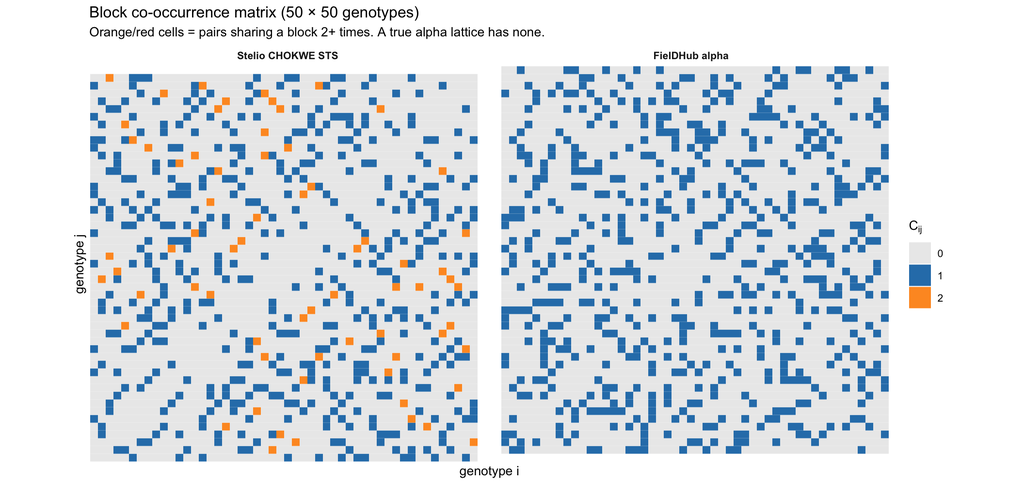

### 7.1.1 Positive control — the same test on a real alpha lattice

A fair skeptic should ask whether this census simply flags *everything* as RCBD. It does not. Running the **identical** count on the FielDHub design generated above — whose true incomplete-block labels (`IBLOCK` within `REP`) are known — recovers the ideal α(0,1) distribution exactly.

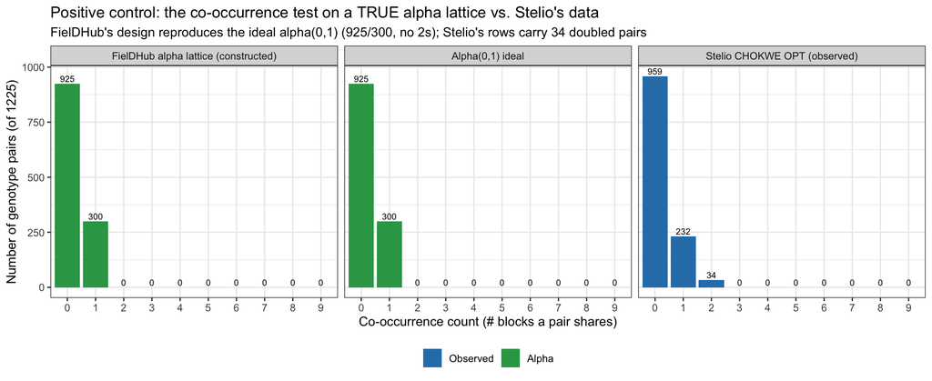

```r
# Census on FielDHub's constructed alpha lattice: block = (REP, IBLOCK), the
# real incomplete blocks. A genuine resolvable alpha(0,1) must show only 0/1.
fh_blk  <- field_book %>% transmute(REP, IBLOCK, gen = ENTRY)
fh_gens <- sort(unique(fh_blk$gen))                 # FielDHub entries 1..50
fh_keys <- combn(fh_gens, 2, FUN = function(p) paste(p[1], p[2], sep = "_"))

fh_counts <- fh_blk %>%
  group_by(REP, IBLOCK) %>%
  summarise(pk = list(combn(sort(gen), 2,
                            FUN = function(p) paste(p[1], p[2], sep = "_"))),
            .groups = "drop") %>%
  tidyr::unnest(pk) %>%
  count(pk, name = "cooc") %>%
  right_join(tibble(pk = fh_keys), by = "pk") %>%
  mutate(cooc = tidyr::replace_na(cooc, 0L)) %>%
  pull(cooc)

# Three panels: constructed alpha | theoretical alpha(0,1) ideal | Stelio (env 1)
ideal_pairs <- numeric(maxc + 1); ideal_pairs[1] <- 925; ideal_pairs[2] <- 300
control_df <- bind_rows(
  dist_row(fh_counts, "FielDHub alpha lattice (constructed)", "Alpha"),
  tibble(count = 0:maxc, pairs = ideal_pairs, panel = "Alpha(0,1) ideal", type = "Alpha"),
  dist_row(cooc_counts(filter(blk, ENV == envs[1]), c("REP", "field_row")),
           paste0("Stelio ", envs[1], " (observed)"), "Observed")
) %>%
  mutate(
    panel = factor(panel, levels = c("FielDHub alpha lattice (constructed)",
                                     "Alpha(0,1) ideal",
                                     paste0("Stelio ", envs[1], " (observed)"))),
    type  = factor(type, levels = c("Observed", "Alpha"))
  )

ggplot(control_df, aes(factor(count), pairs, fill = type)) +
  geom_col() +
  geom_text(aes(label = round(pairs)), vjust = -0.3, size = 2.6) +
  facet_wrap(~ panel, nrow = 1) +
  scale_fill_manual(values = c(Observed = "#2c7fb8", Alpha = "#31a354")) +
  labs(
    title = "Positive control: the co-occurrence test on a TRUE alpha lattice vs. Stelio's data",
    subtitle = "FielDHub's design reproduces the ideal alpha(0,1) (925/300, no 2s); Stelio's rows carry 34 doubled pairs",
    x = "Co-occurrence count (# blocks a pair shares)",
    y = "Number of genotype pairs (of 1225)",
    fill = NULL
  ) +
  theme_bw(base_size = 11) +
  theme(legend.position = "bottom")
```

So the trial **could** have been sown as an alpha lattice — 50 entries split cleanly into 10 blocks of 5, with 3 reps — but the file as delivered carries **no incomplete-block column**, and the co-occurrence census above finds **no repeated sub-block structure** of hybrids within a rep. Therefore:

- The data can be **analyzed as an RCBD today** (the `env:rep` complete block is fully determined by the file).
- The data **cannot be analyzed as an alpha lattice today** — there is no `block` label to put in `env:rep:block`.

## 7.2 What Stelio needs to supply to go alpha

To analyze the *existing* trial as an alpha lattice, exactly one thing is missing: **the incomplete-block (sub-block) assignment that each plot actually had in the field** — Stelio’s fieldbook block column. With it:

```r
# Once a real `block` column exists (1–10 within each env × rep):
alpha_fit <- lmer(
  yield ~ env + (1 | env:rep) + (1 | env:rep:block) +   # <- the alpha term
    (1 | female) + (1 | male) + (1 | cross),
  data = hybrids_with_blocks
)
# Then compare to the RCBD fit on the SAME data:
anova(rcbd_fit, alpha_fit)   # logLik / AIC: does the block term earn its keep?
```

If `alpha_fit` has materially lower AIC (and a non-trivial `env:rep:block` variance), the incomplete blocks captured real within-rep gradient and the alpha analysis is justified. If not, the RCBD is the parsimonious, correct model.

# 8 Summary

```r
summary_tbl <- tibble(
  Aspect = c(
    "What it controls",
    "Mating design (this trial)",
    "Block unit",
    "Within-rep gradient captured",
    "Extra model term vs. RCBD",
    "Needs a sub-block label?",
    "Status for data/multilocation.csv"
  ),
  RCBD = c(
    "Field layout / error control",
    "7 × 7 NC II (unchanged)",
    "Whole replication (50 plots)",
    "No",
    "—",
    "No",
    "Analyzable now (env:rep)"
  ),
  `Alpha lattice` = c(
    "Field layout / error control",
    "7 × 7 NC II (unchanged)",
    "Incomplete block (5 plots)",
    "Yes",
    "env:rep:block",
    "Yes",
    "Needs Stelio's block column first"
  )
)

kable(summary_tbl,
      caption = "RCBD vs. alpha lattice — same NC II genetics, different field-blocking. The mating design is constant; only the blocking term differs.") %>%
  kable_styling(bootstrap_options = c("striped", "hover", "condensed")) %>%
  column_spec(1, bold = TRUE)
```

RCBD vs. alpha lattice — same NC II genetics, different field-blocking. The mating design is constant; only the blocking term differs.

| Aspect | RCBD | Alpha lattice |
| --- | --- | --- |
| What it controls | Field layout / error control | Field layout / error control |
| Mating design (this trial) | 7 × 7 NC II (unchanged) | 7 × 7 NC II (unchanged) |
| Block unit | Whole replication (50 plots) | Incomplete block (5 plots) |
| Within-rep gradient captured | No | Yes |
| Extra model term vs. RCBD | — | env:rep:block |
| Needs a sub-block label? | No | Yes |
| Status for data/multilocation.csv | Analyzable now (env:rep) | Needs Stelio's block column first |

**Bottom line:**

1. *“RCBD with 7 × 7 NC II”* and *“alpha lattice”* are not rivals — the **7 × 7 NC II is the mating design** (constant), while **RCBD vs. alpha lattice is the field layout** choice. They sit on independent axes.
2. The **only** modelling difference is one term: the alpha lattice adds **`env:rep:block`** (incomplete blocks nested in rep) on top of the RCBD’s `env:rep`.
3. An alpha lattice is **dimensionally compatible** with the 50 entries (10 blocks × 5), and FielDHub can generate one — but the **current CSV cannot be analyzed as an alpha lattice** because it has no sub-block column. RCBD (+ optional spatial row/column) is the defensible model **until Stelio provides the real incomplete-block labels**.

# References

Aparicio, J., Ortiz, D., Diaz, S. A., Edwards, J., Eeuwijk, F. van, Bonnett, D., Velazco, J. G., Pacheco, A., Madriz, R., & Crossa, J. (2023). FielDHub: An R Shiny package for the design of experiments in life sciences. *Journal of Open Source Software*, *8*(92), 4769. https://doi.org/10.21105/joss.04769

Comstock, R. E., & Robinson, H. F. (1948). The components of genetic variance in populations of biparental progenies and their use in estimating the average degree of dominance. *Biometrics*, *4*(4), 254–266. https://doi.org/10.2307/3001412

Isik, F., Holland, J., & Maltecca, C. (2017). *Genetic data analysis for plant and animal breeding*. Springer International Publishing. https://doi.org/10.1007/978-3-319-55177-7

Patterson, H. D., & Williams, E. R. (1976). A new class of resolvable incomplete block designs. *Biometrika*, *63*(1), 83–92. https://doi.org/10.1093/biomet/63.1.83